# GERMAN DATA

Pierre TCHUIGOUA

04-01-2024

```
## [1] "C:/Users/tchui/OneDrive/Bureau/Projet_Analyse_donnée_M2_MIASHS/Projet_Elec"
```

## **Introduction**

Le jeu de données contient des informations sur 1000 individus, classés comme étant risqués ou non en fonction d’une variable de réponse.

Dans ce jeu de données, 1 indique une classification **bon emprunteur** tandis que 2 indique **mauvais emprunteur** en termes de risque.

Notre travail consistera en une analyse exploratoire du jeu de données, la construction d’un modèle de régression logistique et la sélection des variables les plus importantes pour prédire si les clients sont classés comme risqués ou non en se basant sur les informations fournies sur les individus.

| V1 | V2 | V3 | V4 | V5 | V6 | V7 | V8 | V9 | V10 | V11 | V12 | V13 | V14 | V15 | V16 | V17 | V18 | V19 | V20 | V21 |
| --- | --- | --- | --- | --- | --- | --- | --- | --- | --- | --- | --- | --- | --- | --- | --- | --- | --- | --- | --- | --- |
| A11 | 6 | A34 | A43 | 1169 | A65 | A75 | 4 | A93 | A101 | 4 | A121 | 67 | A143 | A152 | 2 | A173 | 1 | A192 | A201 | 1 |
| A12 | 48 | A32 | A43 | 5951 | A61 | A73 | 2 | A92 | A101 | 2 | A121 | 22 | A143 | A152 | 1 | A173 | 1 | A191 | A201 | 2 |
| A14 | 12 | A34 | A46 | 2096 | A61 | A74 | 2 | A93 | A101 | 3 | A121 | 49 | A143 | A152 | 1 | A172 | 2 | A191 | A201 | 1 |
| A11 | 42 | A32 | A42 | 7882 | A61 | A74 | 2 | A93 | A103 | 4 | A122 | 45 | A143 | A153 | 1 | A173 | 2 | A191 | A201 | 1 |
| A11 | 24 | A33 | A40 | 4870 | A61 | A73 | 3 | A93 | A101 | 4 | A124 | 53 | A143 | A153 | 2 | A173 | 2 | A191 | A201 | 2 |
| A14 | 36 | A32 | A46 | 9055 | A65 | A73 | 2 | A93 | A101 | 4 | A124 | 35 | A143 | A153 | 1 | A172 | 2 | A192 | A201 | 1 |
| A14 | 24 | A32 | A42 | 2835 | A63 | A75 | 3 | A93 | A101 | 4 | A122 | 53 | A143 | A152 | 1 | A173 | 1 | A191 | A201 | 1 |
| A12 | 36 | A32 | A41 | 6948 | A61 | A73 | 2 | A93 | A101 | 2 | A123 | 35 | A143 | A151 | 1 | A174 | 1 | A192 | A201 | 1 |
| A14 | 12 | A32 | A43 | 3059 | A64 | A74 | 2 | A91 | A101 | 4 | A121 | 61 | A143 | A152 | 1 | A172 | 1 | A191 | A201 | 1 |
| A12 | 30 | A34 | A40 | 5234 | A61 | A71 | 4 | A94 | A101 | 2 | A123 | 28 | A143 | A152 | 2 | A174 | 1 | A191 | A201 | 2 |

On appelera :

Status of existing checking account **Status_compte_depot**

Installment rate in percentage of disposable income **installment_rate**

Number of existing credits at this bank **nbre_credit_dans_la_bank**

Number of people being liable to provide maintenance for **nombre_de_garants**

| Status_compte_depot | durée_en_mois | Credit_history | Purpose | Credit_amount | Savings_account_bonds | Present_employment_since | installment_rate | Personal_status_and_sex | Other_debtors_guarantors | Present_residence_since | Property | Age | Other_installment_plans | Housing | nbre_credit_dans_la_bank | Job | nbre_de_garants | Telephone | foreign worker | Y |
| --- | --- | --- | --- | --- | --- | --- | --- | --- | --- | --- | --- | --- | --- | --- | --- | --- | --- | --- | --- | --- |
| A11 | 6 | A34 | A43 | 1169 | A65 | A75 | 4 | A93 | A101 | 4 | A121 | 67 | A143 | A152 | 2 | A173 | 1 | A192 | A201 | 1 |
| A12 | 48 | A32 | A43 | 5951 | A61 | A73 | 2 | A92 | A101 | 2 | A121 | 22 | A143 | A152 | 1 | A173 | 1 | A191 | A201 | 2 |
| A14 | 12 | A34 | A46 | 2096 | A61 | A74 | 2 | A93 | A101 | 3 | A121 | 49 | A143 | A152 | 1 | A172 | 2 | A191 | A201 | 1 |
| A11 | 42 | A32 | A42 | 7882 | A61 | A74 | 2 | A93 | A103 | 4 | A122 | 45 | A143 | A153 | 1 | A173 | 2 | A191 | A201 | 1 |
| A11 | 24 | A33 | A40 | 4870 | A61 | A73 | 3 | A93 | A101 | 4 | A124 | 53 | A143 | A153 | 2 | A173 | 2 | A191 | A201 | 2 |
| A14 | 36 | A32 | A46 | 9055 | A65 | A73 | 2 | A93 | A101 | 4 | A124 | 35 | A143 | A153 | 1 | A172 | 2 | A192 | A201 | 1 |

```
## les variables catégorielles sont les suivantes :
##
##
##  Status_compte_depot Credit_history Purpose Savings_account_bonds Present_employment_since Personal_status_and_sex Other_debtors_guarantors Property Other_installment_plans Housing Job Telephone foreign worker
```

```
## les variables quantitatives sont les suivantes :
##
##  durée_en_mois Credit_amount installment_rate Present_residence_since Age nbre_credit_dans_la_bank nbre_de_garants Y
```

```
## nombre de bons payeurs 700
##  nombre de mauvais payeurs 300
```

## **ANALYSE EXPLORATOIRE**

Il y a un total de 21 variables (*Y* inclus) dans l’ensemble du jeu de données. Nous avons essayé de lister leurs signification en français :

État du compte dépot existant Durée en mois Historique de crédit Montant du crédit Comptes d’épargne / obligations Emploi actuel depuis Taux d’acompte en pourcentage du revenu disponible Situation personnelle et sexe Autres débiteurs / garants Résidence actuelle depuis Propriété Âge en années Autres plans d’acompte Logement Nombre de crédits existants dans cette banque Emploi Nombre de garants Téléphone Travailleur étranger

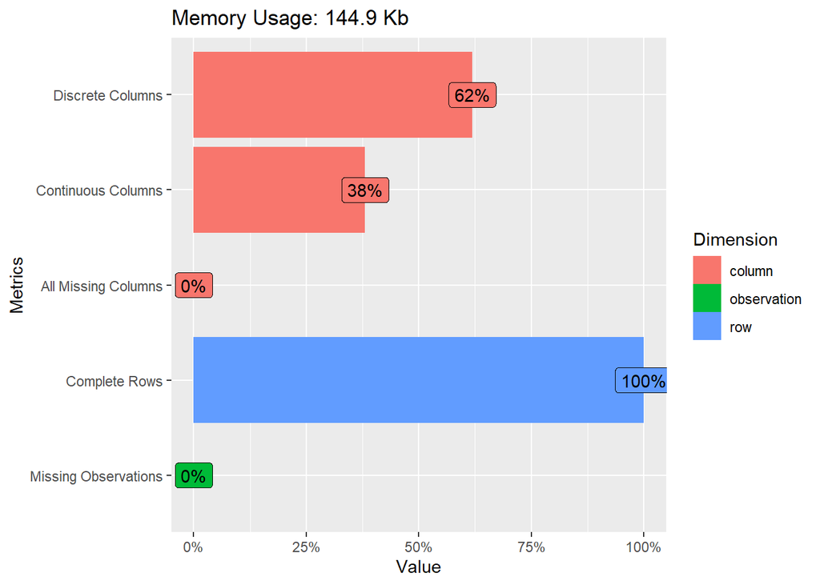

La bonne nouvelle ici c’est qu’on n’a pas de valeurs manquantes.

## **Résumé**

|  | Status_compte_depot | durée_en_mois | Credit_history | Purpose | Credit_amount | Savings_account_bonds | Present_employment_since | installment_rate | Personal_status_and_sex | Other_debtors_guarantors | Present_residence_since | Property | Age | Other_installment_plans | Housing | nbre_credit_dans_la_bank | Job | nbre_de_garants | Telephone | foreign worker | Y |
| --- | --- | --- | --- | --- | --- | --- | --- | --- | --- | --- | --- | --- | --- | --- | --- | --- | --- | --- | --- | --- | --- |
|  | Length:1000 | Min. : 4.0 | Length:1000 | Length:1000 | Min. : 250 | Length:1000 | Length:1000 | Min. :1.000 | Length:1000 | Length:1000 | Min. :1.000 | Length:1000 | Min. :19.00 | Length:1000 | Length:1000 | Min. :1.000 | Length:1000 | Min. :1.000 | Length:1000 | Length:1000 | Min. :0.0 |
|  | Class :character | 1st Qu.:12.0 | Class :character | Class :character | 1st Qu.: 1366 | Class :character | Class :character | 1st Qu.:2.000 | Class :character | Class :character | 1st Qu.:2.000 | Class :character | 1st Qu.:27.00 | Class :character | Class :character | 1st Qu.:1.000 | Class :character | 1st Qu.:1.000 | Class :character | Class :character | 1st Qu.:0.0 |
|  | Mode :character | Median :18.0 | Mode :character | Mode :character | Median : 2320 | Mode :character | Mode :character | Median :3.000 | Mode :character | Mode :character | Median :3.000 | Mode :character | Median :33.00 | Mode :character | Mode :character | Median :1.000 | Mode :character | Median :1.000 | Mode :character | Mode :character | Median :1.0 |
|  | NA | Mean :20.9 | NA | NA | Mean : 3271 | NA | NA | Mean :2.973 | NA | NA | Mean :2.845 | NA | Mean :35.55 | NA | NA | Mean :1.407 | NA | Mean :1.155 | NA | NA | Mean :0.7 |
|  | NA | 3rd Qu.:24.0 | NA | NA | 3rd Qu.: 3972 | NA | NA | 3rd Qu.:4.000 | NA | NA | 3rd Qu.:4.000 | NA | 3rd Qu.:42.00 | NA | NA | 3rd Qu.:2.000 | NA | 3rd Qu.:1.000 | NA | NA | 3rd Qu.:1.0 |
|  | NA | Max. :72.0 | NA | NA | Max. :18424 | NA | NA | Max. :4.000 | NA | NA | Max. :4.000 | NA | Max. :75.00 | NA | NA | Max. :4.000 | NA | Max. :2.000 | NA | NA | Max. :1.0 |

## **ANALYSE EXPLORATOIRE**

### **Matrice de corrélation des variables quantitatives**

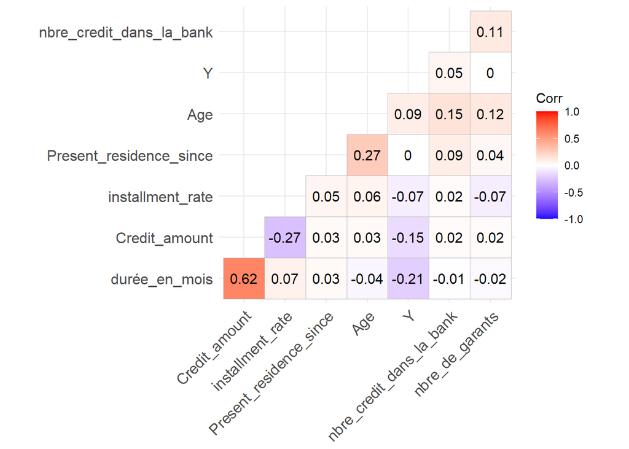

On peut constater que les variables **Credit_amount** et **durée_en_mois** présentent une corrélation négative avec la réponse **Y**, tandis que l’âge a un impact positif sur celle-ci.

Ainsi, un montant et une durée plus élevés impliquent que la valeur de la réponse sera également plus petite, c’est-à-dire plus proche de 0. Par conséquent, cela augmente la probabilité d’un risque de crédit élevé, c’est-à-dire un mauvais client.

Nous divisons maintenant notre ensemble de données en deux parties : l’une avec des clients classés comme bons, et l’autre avec des clients classés comme mauvais. Les ensembles de données contiennent respectivement 700 et 300 observations. La répartition des variables pour chaque ensemble est également vérifiée.

Enfin une forte corrélation entre le montant de l’emprunt et la durée.

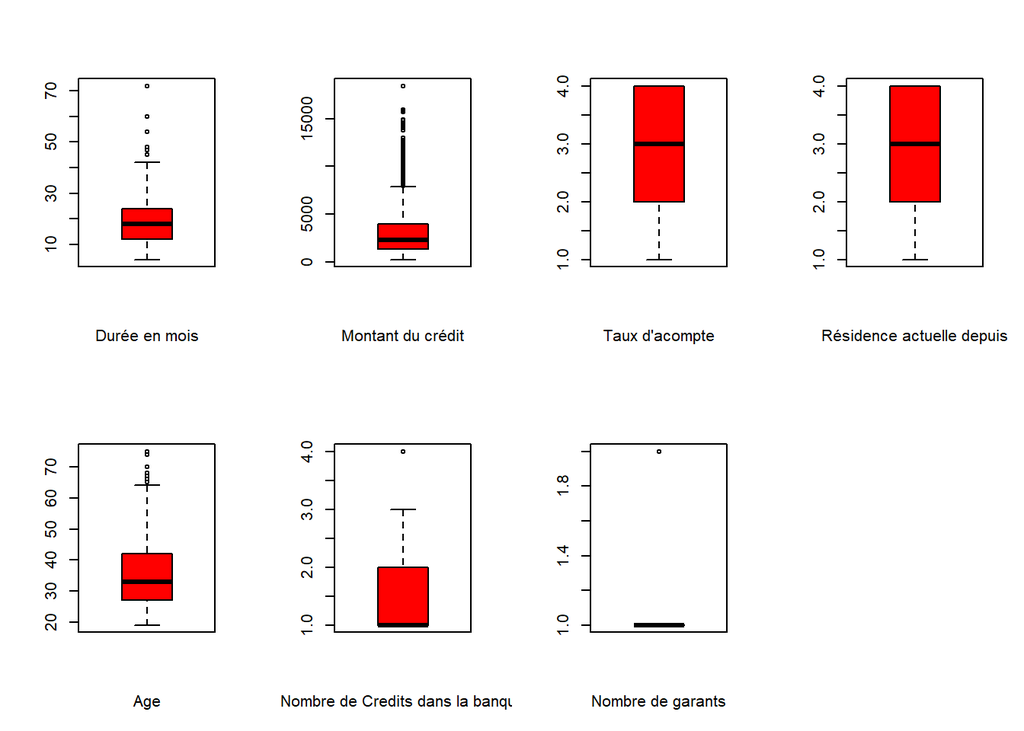

**Durée en mois et Montant crédit**

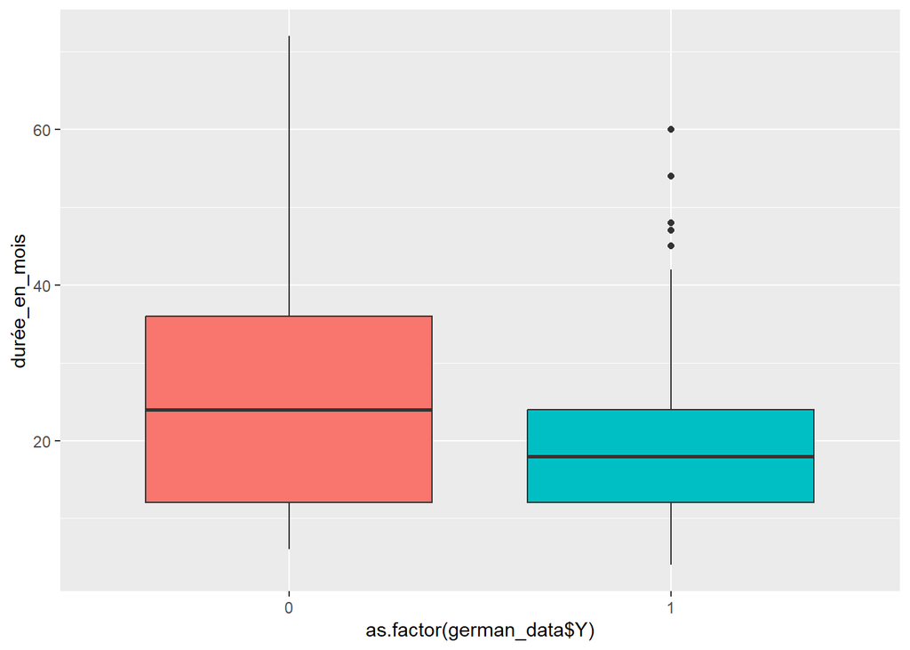

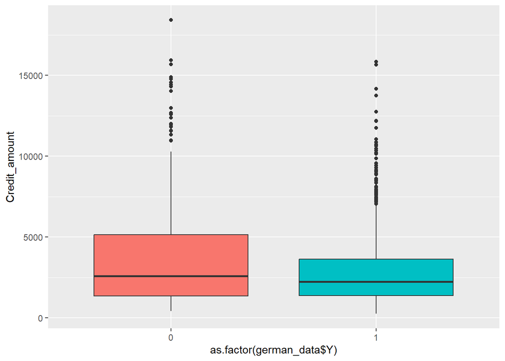

Obeservation:

La valeur médiane et la longueur de la boite **durée en mois** semblent être plus élevées pour les mauvais clients comparées à celles des bons clients. Donc plus la durée est longue plus la personne a des chances de faire défaut.

Pour le montant du crédit **credit_amount**, les valeurs médianes sont assez proches.

*AGE*

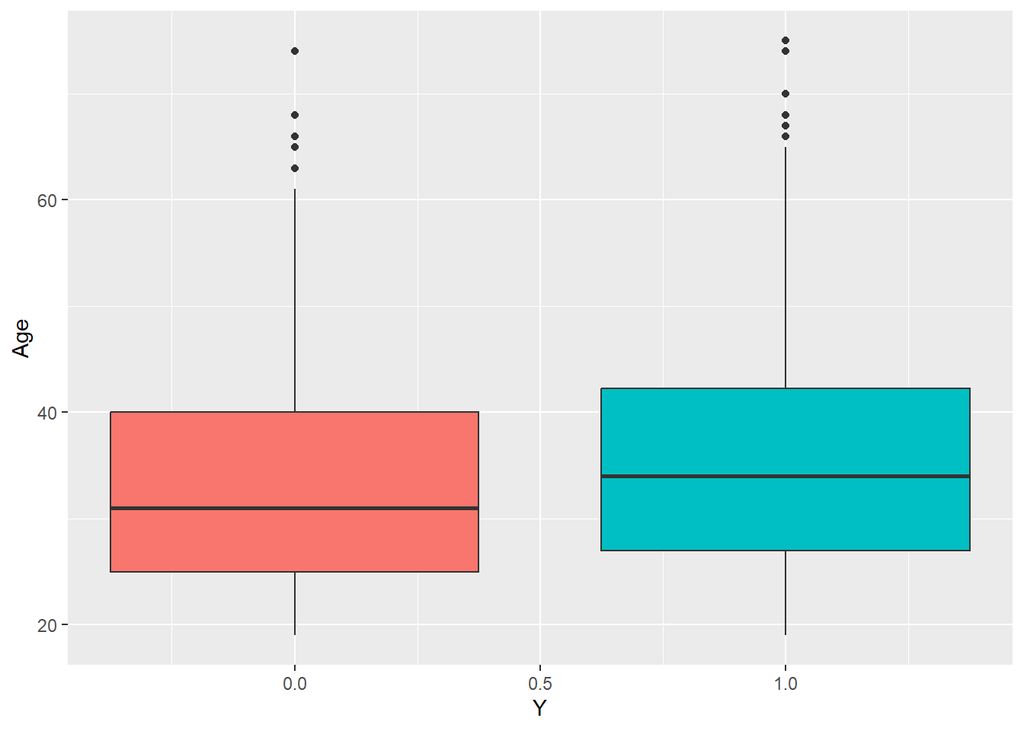

Pour la variable *Age*, l’âge médian pour les *mauvais payeurs* est plus petit que celui des personnes dites *bons payeurs*.

On peut donc dire que plus on est jeune, plus on est un client à risque.

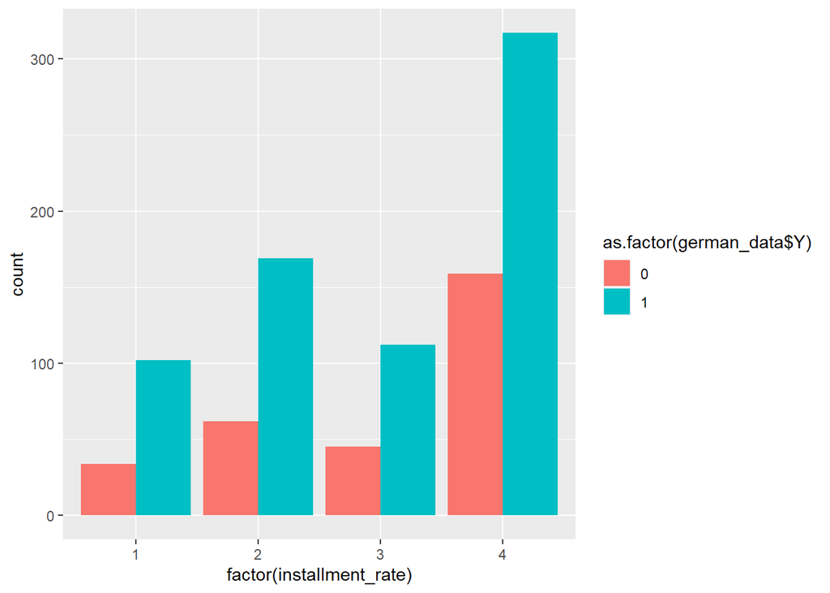

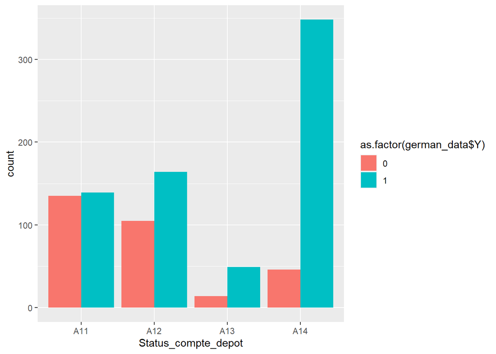

La variable **Statut_compte_depot** est un compte tenu dans une institution financière qui permet des retraits et des dépots (sorte de compte courrant)

Ses modalités sont : A11 : … < 0 DM (à découvert) A12 : 0 <= … < 200 DM A13 : … >= 200 DM

salary assignments for at least 1 year A14 : no checking account

```
              (DM pour deutsch mark)
```

Pour cette variable, les modalités **A11** et **A12** ne présentent pas beaucoup de différence entre les bons et les mauvais payeurs.

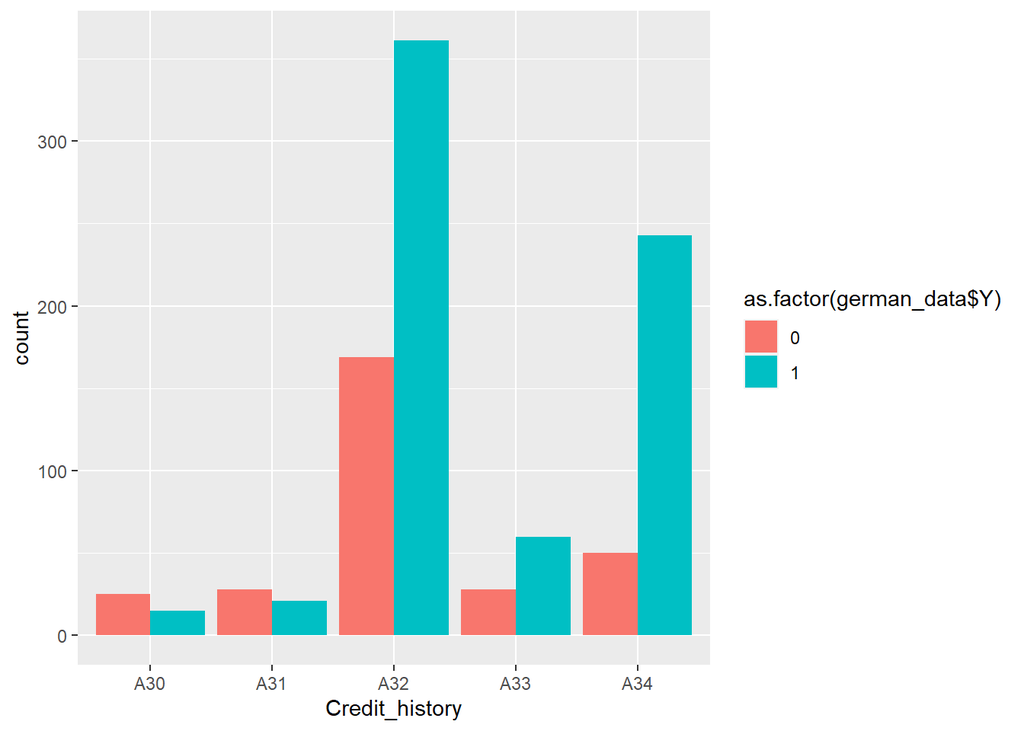

Pour les modalités de **A32** à **A34** de l’historique de crédit **Credit_history**, les bons payeurs sont plus nombreux que les mauvais payeurs par rapport aux modalités **A30** et **A31**

La tendance est la même pour les autres variables : sex, other_debtor,saving_acct, other_install and foreign. Nous ne les ferons pas.

## **Analyse bivariée**

### **Identification des variables les plus discriminantes**

|  | x |
| --- | --- |
| Present_residence_since | 0.0000088 |
| nbre_de_garants | 0.0000091 |
| nbre_credit_dans_la_bank | 0.0020915 |
| installment_rate | 0.0052423 |
| Age | 0.0083042 |
| Credit_amount | 0.0239440 |
| durée_en_mois | 0.0461935 |
| Y | 1.0000000 |

Parmi les variables quantitatives, les liaisons les plus fortes sont observées pour les variables **durée_en_mois** et **Credit_amount**.

Au contraire, les variables **nbre_of_peopl_liable_prov_mainten_for** et **Present_residence_since** n’apparaissent pas comme discriminantes.

En prévision des variables à utiliser pour construire un modèle de régression logistique, on considère les associations entre la variable Y et les autres variables catégorielles.

## **Observation** :

L’âge du client a une influence la probabilité d’être bon ou mauvais payeur.

Le **Purpose** traduit comme la raison du prêt présente des modalités différentes listées dans cet ordre :

```
    A40 : car (new)
      A41 : car (used)
      A42 : furniture/equipment
      A43 : radio/television
      A44 : domestic appliances
      A45 : repairs
      A46 : education
      A47 : (vacation - does not exist?)
      A48 : retraining
      A49 : business
      A410 : others
```

On peut écrire un modèle en contrôlant le motif du prêt (classés en essentiel ou non essentiel, avec les appareils domestiques, les réparations, l’éducation et la reconversion considérés comme essentiels) ainsi que le montant du prêt **Credit_amount**.

Au cours de cette analyse, nous prendrons en compte le motif du prêt parce qu’il est possible que le prêt soit plus susceptible d’être mauvais si une personne jeune contracte un prêt pour quelque chose comme une voiture ou une télévision, car cette personne pourrait être irresponsable et acheter une voiture/télévision coûteuse sans savoir comment rembourser le prêt.

D’où un modèle avec intéraction.

Cependant, pour des choses essentielles telles que l’éducation et les réparations, nous ne nous attendons pas à voir ce type de différence entre les jeunes et les personnes plus âgées. Essayons de modéliser cela avec une interaction et sans interaction, et décidons s’il est pertinent d’inclure cette interaction dans notre analyse.

## **Premier modèle**

```
##
## Call:  glm(formula = Y ~ Age + Essentiel + Credit_amount + Age * Essentiel,
##     family = binomial, data = german_data)
##
## Coefficients:
##                (Intercept)                         Age
##                  0.0221352                   0.0217041
##     EssentielNon-Essentiel               Credit_amount
##                  0.5454626                  -0.0001205
## Age:EssentielNon-Essentiel
##                 -0.0004812
##
## Degrees of Freedom: 999 Total (i.e. Null);  995 Residual
## Null Deviance:       1222
## Residual Deviance: 1184  AIC: 1194
```

```
##
## Call:  glm(formula = Y ~ Age + Essentiel + Credit_amount, family = binomial,
##     data = german_data)
##
## Coefficients:
##            (Intercept)                     Age  EssentielNon-Essentiel
##              0.0375606               0.0212871               0.5278805
##          Credit_amount
##             -0.0001206
##
## Degrees of Freedom: 999 Total (i.e. Null);  996 Residual
## Null Deviance:       1222
## Residual Deviance: 1184  AIC: 1192
```

```
## AIC du modèle 0 avec intéraction : 1194.126
```

```
## AIC du modèle 0 sans intéraction : 1192.126
```

**A priori le modèle sans intéraction est meilleur car présentant un AIC plus faible.**

```
##
## Call:
## glm(formula = Y ~ Age + Essentiel + Credit_amount, family = binomial,
##     data = german_data)
##
## Coefficients:
##                          Estimate Std. Error z value Pr(>|z|)
## (Intercept)             3.756e-02  3.297e-01   0.114  0.90930
## Age                     2.129e-02  6.606e-03   3.222  0.00127 **
## EssentielNon-Essentiel  5.279e-01  2.324e-01   2.272  0.02311 *
## Credit_amount          -1.206e-04  2.394e-05  -5.037 4.73e-07 ***
## ---
## Signif. codes:  0 '***' 0.001 '**' 0.01 '*' 0.05 '.' 0.1 ' ' 1
##
## (Dispersion parameter for binomial family taken to be 1)
##
##     Null deviance: 1221.7  on 999  degrees of freedom
## Residual deviance: 1184.1  on 996  degrees of freedom
## AIC: 1192.1
##
## Number of Fisher Scoring iterations: 4
```

La variable **Age** a une p-value < 5%.

On rejete l’hypothèse que l’âge ne détermine pas si oui ou non la personne est un bon payeur ou non avec une confiance de 95%.

Donc, les personnes agées sont plutôt bons payeurs.

### **Données d’entrainement et données de Test**

On commence par divise notre ensemble de données en ensembles d’entraînement et de test. Puis sélectionnons de manière aléatoire 80 % des observations pour former l’ensemble d’entraînement et 20 % des observations pour former l’ensemble de test. Le modèle sera construit à partir de l’ensemble d’entraînement et sera évalué sur l’ensemble de test.

### **Modèle logistique**

Étant donné que la variable réponse *Y* est bianire, donc nous classifions le client comme bon ou mauvais en fonction du risque de crédit, nous utilisons la technique de régression logistique pour créer le modèle.

### **Modèle avec le critère de AIC**

Elaborons deux modèles, le modèle 1 est le modèle nul contenant uniquement la variable réponse *Y* .

Le modèle 2 est le modèle complet contenant les 20 variables.

Puis, sélectionnons le meilleur modèle en utilisant la méthode de sélection pas à pas - avec le **critère AIC.**

```
## Start:  AIC=803.91
## Y ~ Status_compte_depot + durée_en_mois + Credit_history + Purpose +
##     Credit_amount + Savings_account_bonds + Present_employment_since +
##     installment_rate + Personal_status_and_sex + Other_debtors_guarantors +
##     Present_residence_since + Property + Age + Other_installment_plans +
##     Housing + nbre_credit_dans_la_bank + Job + nbre_de_garants +
##     Telephone + `foreign worker` + Essentiel
##
##
## Step:  AIC=803.91
## Y ~ Status_compte_depot + durée_en_mois + Credit_history + Purpose +
##     Credit_amount + Savings_account_bonds + Present_employment_since +
##     installment_rate + Personal_status_and_sex + Other_debtors_guarantors +
##     Present_residence_since + Property + Age + Other_installment_plans +
##     Housing + nbre_credit_dans_la_bank + Job + nbre_de_garants +
##     Telephone + `foreign worker`
##
##                            Df Deviance    AIC
## - Property                  3   707.60 799.60
## - Present_residence_since   1   705.93 801.93
## - Job                       3   710.19 802.19
## - nbre_de_garants           1   706.42 802.42
## - nbre_credit_dans_la_bank  1   706.98 802.98
## - Housing                   2   709.09 803.09
## - durée_en_mois             1   707.43 803.43
## <none>                          705.91 803.91
## - Present_employment_since  4   713.93 803.93
## - Other_debtors_guarantors  2   711.25 805.25
## - Age                       1   710.28 806.28
## - Telephone                 1   710.76 806.76
## - `foreign worker`          1   711.55 807.55
## - Savings_account_bonds     4   719.47 809.47
## - Other_installment_plans   2   715.70 809.70
## - Personal_status_and_sex   3   718.07 810.07
## - Credit_history            4   726.61 816.61
## - installment_rate          1   721.77 817.77
## - Credit_amount             1   725.26 821.26
## - Purpose                   9   743.46 823.46
## - Status_compte_depot       3   761.68 853.68
##
```

[output cut: 194 more lines]

```
## - Other_debtors_guarantors  2   727.03 793.03
## - Age                       1   725.25 793.25
## + Present_employment_since  4   715.39 793.39
## + Property                  3   718.50 794.50
## + Job                       3   718.70 794.70
## - Telephone                 1   727.62 795.62
## - `foreign worker`          1   728.13 796.13
## - Savings_account_bonds     4   735.32 797.32
## - Personal_status_and_sex   3   733.96 797.96
## - Other_installment_plans   2   733.14 799.14
## - Credit_history            4   741.84 803.84
## - installment_rate          1   740.25 808.25
## - Purpose                   9   758.29 810.29
## - Credit_amount             1   760.02 828.02
## - Status_compte_depot       3   779.53 843.53
```

```
##
## Call:
## glm(formula = Y ~ Status_compte_depot + Credit_history + Purpose +
##     Credit_amount + Savings_account_bonds + installment_rate +
##     Personal_status_and_sex + Other_debtors_guarantors + Age +
##     Other_installment_plans + Housing + Telephone + `foreign worker`,
##     family = "binomial", data = german.train)
##
## Coefficients:
##                                Estimate Std. Error z value Pr(>|z|)
## (Intercept)                  -2.6222039  0.8273467  -3.169 0.001527 **
## Status_compte_depotA12        0.4793440  0.2419898   1.981 0.047609 *
## Status_compte_depotA13        1.2480718  0.4135839   3.018 0.002547 **
## Status_compte_depotA14        1.7700573  0.2544867   6.955 3.52e-12 ***
## Credit_historyA31             0.1707199  0.6007413   0.284 0.776271
## Credit_historyA32             0.8593252  0.4740783   1.813 0.069890 .
## Credit_historyA33             1.0712777  0.5468776   1.959 0.050125 .
## Credit_historyA34             1.6382099  0.4972905   3.294 0.000987 ***
## PurposeA41                    1.8960378  0.4135077   4.585 4.53e-06 ***
## PurposeA410                   1.5868378  0.8771685   1.809 0.070444 .
## PurposeA42                    0.9087614  0.2936648   3.095 0.001971 **
## PurposeA43                    0.8938609  0.2672739   3.344 0.000825 ***
## PurposeA44                    0.0427623  0.8514065   0.050 0.959943
## PurposeA45                    0.3727593  0.5776911   0.645 0.518761
## PurposeA46                   -0.1945234  0.4274885  -0.455 0.649082
## PurposeA48                    2.0540465  1.2671631   1.621 0.105022
## PurposeA49                    0.7447684  0.3822883   1.948 0.051393 .
## Credit_amount                -0.0002355  0.0000394  -5.977 2.27e-09 ***
## Savings_account_bondsA62      0.2386182  0.3150836   0.757 0.448860
## Savings_account_bondsA63      0.3516378  0.4762695   0.738 0.460322
## Savings_account_bondsA64      1.5754687  0.6227193   2.530 0.011407 *
## Savings_account_bondsA65      0.7815065  0.2853555   2.739 0.006168 **
## installment_rate             -0.4103783  0.0954115  -4.301 1.70e-05 ***
## Personal_status_and_sexA92    0.5218369  0.4112917   1.269 0.204521
## Personal_status_and_sexA93    1.1405007  0.4036630   2.825 0.004722 **
## Personal_status_and_sexA94    0.9927664  0.5088472   1.951 0.051056 .
## Other_debtors_guarantorsA102 -0.5674460  0.4279915  -1.326 0.184894
## Other_debtors_guarantorsA103  0.9063401  0.4618118   1.963 0.049696 *
## Age                           0.0198820  0.0093440   2.128 0.033355 *
## Other_installment_plansA142  -0.1154788  0.4556808  -0.253 0.799943
## Other_installment_plansA143   0.8239114  0.2641133   3.120 0.001811 **
## HousingA152                   0.4518618  0.2503929   1.805 0.071136 .
## HousingA153                  -0.1690838  0.3884621  -0.435 0.663370
## TelephoneA192                 0.5469640  0.2089570   2.618 0.008855 **
## `foreign worker`A202          1.7972843  0.7505084   2.395 0.016631 *
## ---
## Signif. codes:  0 '***' 0.001 '**' 0.01 '*' 0.05 '.' 0.1 ' ' 1
##
## (Dispersion parameter for binomial family taken to be 1)
##
##     Null deviance: 1002.99  on 799  degrees of freedom
## Residual deviance:  720.62  on 765  degrees of freedom
## AIC: 790.62
##
## Number of Fisher Scoring iterations: 5
```

Le modèle sélectionné selon le critère AIC comporte 13 variables. Ce modèle exclut les variables suivantes :

**Present_employment_since**, **Present_residence_since**, **job**, **Property**, **durée_en_mois**, **nbre_de garants**, **nbre_credit_dans_la_bank**

## **Performance du modèle sur les données d’échantillon**

Utilisons le modèle généré par régression logistique pour tracer la courbe **ROC** (vrais positifs vs faux positifs) en utilisant les données d’entraînement et trouverl’aire sous la courbe (**AUC**).

Une valeur élevée de l’**AUC** indiquera une meilleure performance du modèle.

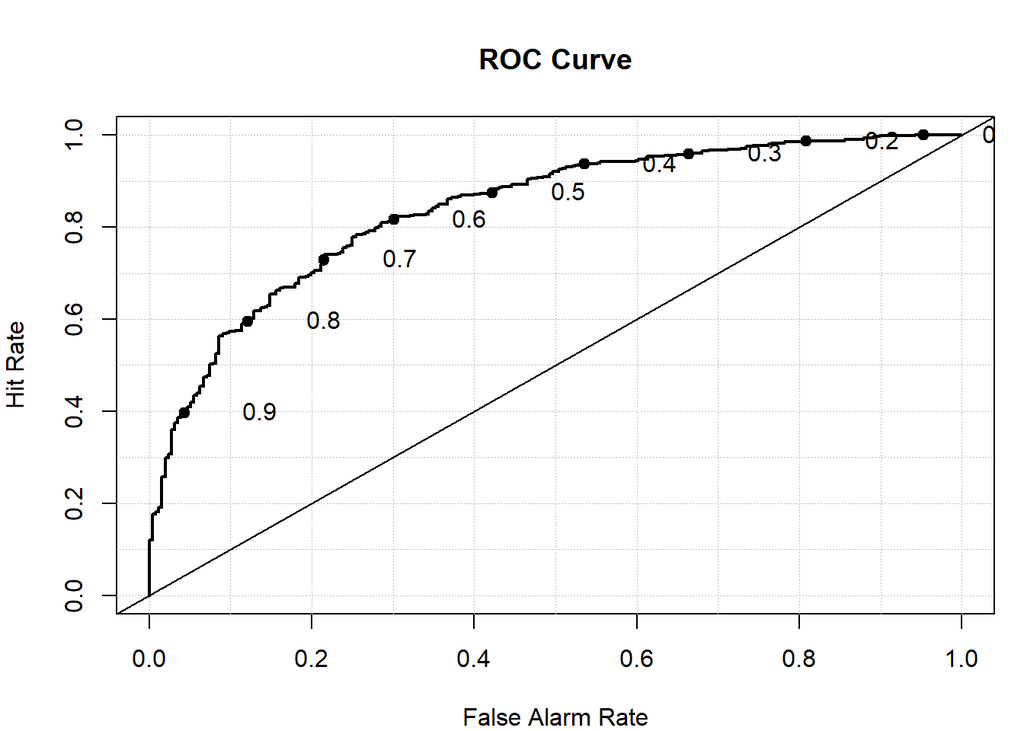

```
##      Model      Area      p.value binorm.area
## 1 Model  1 0.8397791 1.274375e-54          NA
```

La valeur de l’AUC de l’ensemble de données d’entraînement est de **0.8397.**

En observant le taux de mauvaise classification, nous trouvons un seuil de probabilité optimal dérivé en utilisant la fonction de coût asymétrique (le poids pour un risque de crédit élevé est choisi comme étant 5 par rapport à 1 pour un risque de crédit faible).

La fonction de coût implique que classifier à tort des clients qui devraient être classés comme mauvais coûte 5 fois plus que de classifier à tort des clients qui devraient être classés comme Bons.

Représentons graphiquement la fonction de coût dans l’ensemble de données d’entraînement par rapport au seuil de probabilité.

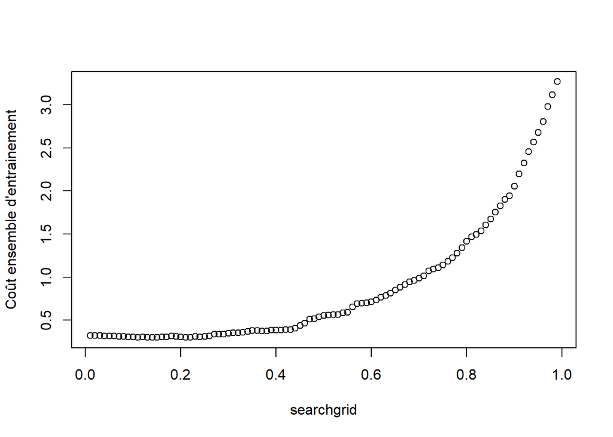

```
## [1] 0.13
```

Cherchons le taux de mauvaise classification en utilisant cette valeur.

```
##     true
## pred   0   1
##    0  21   1
##    1 235 543
```

```
## taux de mauvaise classeification :  0.295
```

## **Données de Test**

Testons le modèle créé à l’aide de l’ensemble de données d’entraînement sur l’ensemble de données de test contenant 20 % des observations.

L’objectif est de trouver l’AUC et le taux de mauvaise classification.

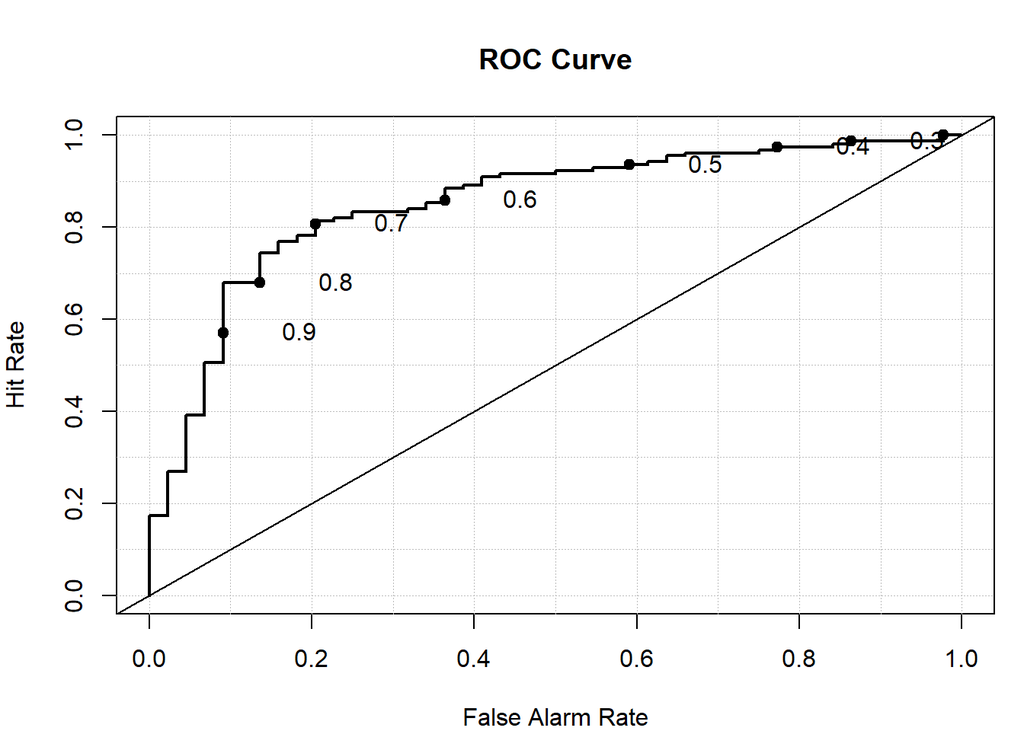

```
##      Model      Area      p.value binorm.area
## 1 Model  1 0.8511072 5.968699e-13          NA
```

La valeur de l’AUC est de 0.8511.

Calculonq le taux de classification pour l’ensemble de données de test. Il est à noter que nous utiliserons la valeur du seuil de probabilité à 0,13 (la valeur que nous avions déterminée en utilisant la fonction de coût).

```
##     true
## pred   0   1
##    1  44 156
```

```
## Le taux de mauvaise classification :  0.22
```

Le taux de mauvaise classification **0.22**.

En observant les résultats, on peut dire que le modèle est précis à environ 78 % dans la prédiction de la classification du risque de crédit pour les clients dans l’ensemble de données de test.

## **Conclusion de l’analyse**

On peut dire que le modèle final créé pour classifier les clients en fonction du risque de crédit à l’aide de la régression logistique contient 13 variables. Les performances dans l’échantillon et hors échantillon de ce modèle sont comparables.